# Part II - Communicating Data Findings

## by Peace Ugbekile

## Investigation Overview

> In this presentation, I will be showcasing how certain variables affect borrowers' ability to complete their loan repayment as well as some factors that affect their Annual Percentage Rate (APR).

## Dataset Overview

> The dataset for exploration contains a total of 77556 loans with 16 loan attributes.

## Loan Distribution by Year and Month

> The number of loan availment is highest in January and loan disbursement increased at an increasing rate between 2009 - 2013 and then declined in 2014. This could have been because of the increase in defaults or bad loans.

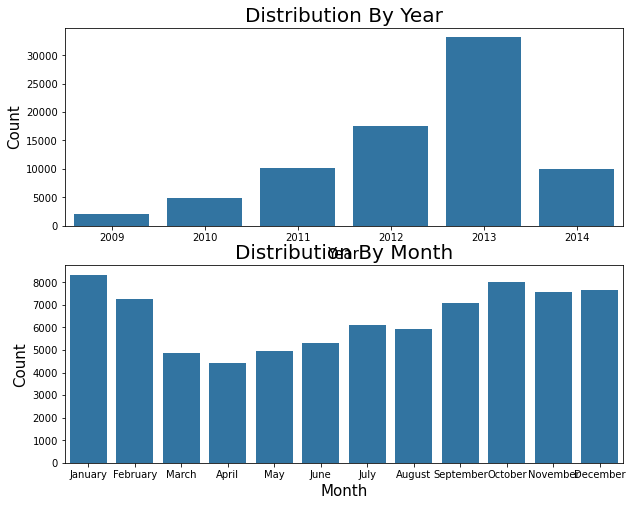

## Distribution of Loan Status

> The currently running loans and completed loan are more than defaults for the period under observation.

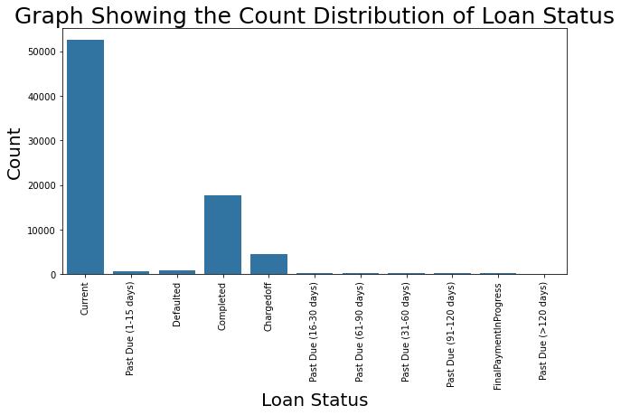

## Distribution of Borrowers' APR

> Borrowers' Annual Percentage Rate is multimodal with the highest peak found between 0.35 and 0.37 and infinitesimal number of loans with APR greater than 0.4.

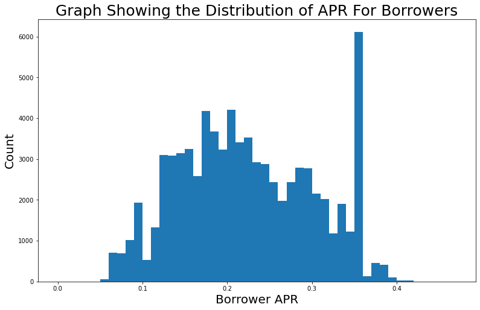

## Distribution of Monthly Income

> Monthly income is extremely right skewed with majority of the borrowers earning within the mean income amount of about 5,964 dollars and extremely few persons earning above 15,000 dollars.

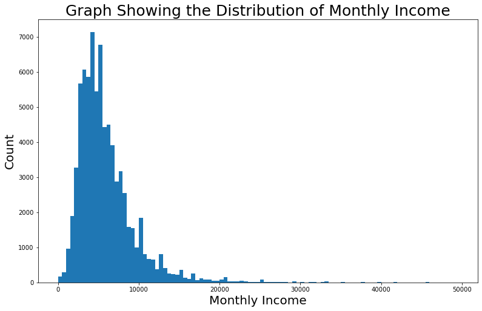

## Loan Status vs Original Loan Amount

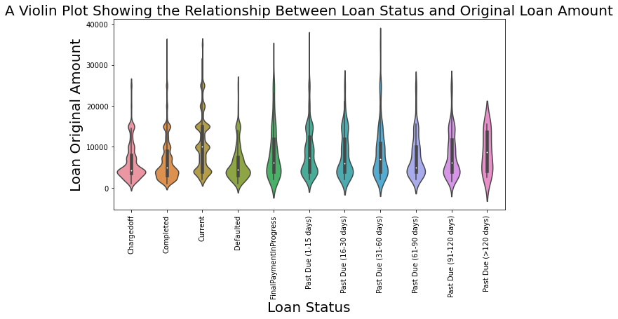

## Loan Status vs Monthly Income

> The mean income for completed, current and payment in progress loans was higher than all other forms of bad or defaulting loans. This further strengthens the hypothesis that income affects ability to pay down on loans.

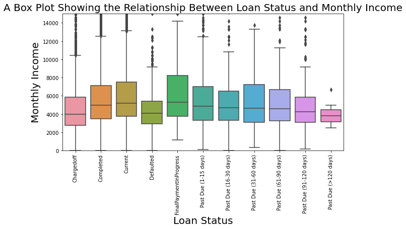

## Borrowers' APR vs Loan Amount

> Borrower APR is negatively correlated with loan original amount suggesting that the more the loan amount, the lower the APR.

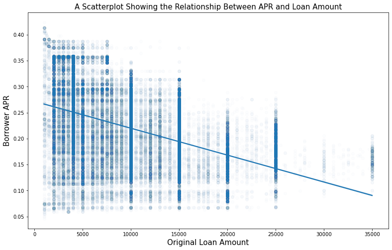

## Borrowers' APR vs Prosper Score

> The borrower APR decreases with the increasingly better prosper score. Borrowers with the best Prosper scores have the lowest APR. It means that the Prosper rating has a strong effect on borrower APR.

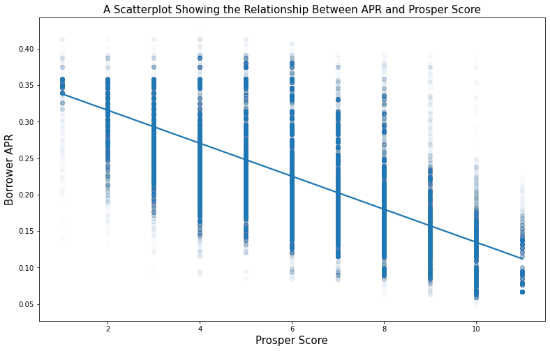

## Loan Status vs Borrowers' Rate

> The mean interest rate for "completed" loans, "current" loans and "final payment in progress" loans was lower than for defaulting and other bad loans (past due).

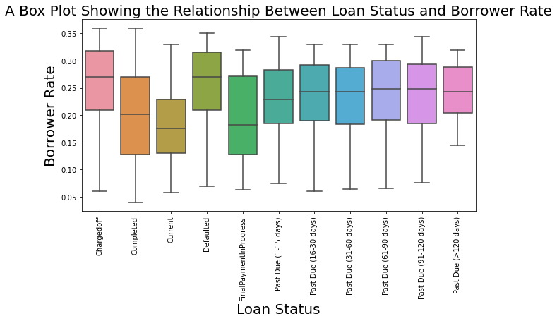